# Predicting Barbell Lift Quality from Wearable Sensor Data

Sujal

27 October 2026

## 1. Executive summary

Six participants performed barbell lifts while wearing accelerometers on the belt, forearm and arm, with one more sensor on the dumbbell. Each repetition was done either correctly (class **A**) or with one of four common mistakes (classes **B–E**). The goal is to predict the `classe` variable from the sensor readings.

After removing ID columns, near-empty summary columns and near-zero-variance predictors, **52 sensor features** remained. I compared a single decision tree with a **random forest**, using 5-fold cross-validation on 70 % of the data and keeping the other 30 % as an untouched validation set. The random forest was far better — over 99 % accuracy on the hold-out set, an expected out-of-sample error well under 1 % (exact figures in sections 6 and 7) — and it was used to predict the 20 test cases.

## 2. Data source

The data is the *Weight Lifting Exercise Dataset* by Velloso, Bulling, Gellersen, Ugulino and Fuks (2013), *Qualitative Activity Recognition of Weight Lifting Exercises*, Proceedings of the 4th Augmented Human International Conference. Original site: http://web.archive.org/web/20161224072740/http:/groupware.les.inf.puc-rio.br/har. I thank the authors for allowing its use in this assignment.

The five classes are:

| Class | How the lift was performed |
| --- | --- |
| A | Exactly according to the specification (correct) |
| B | Throwing the elbows to the front |
| C | Lifting the dumbbell only halfway |
| D | Lowering the dumbbell only halfway |
| E | Throwing the hips to the front |

## 3. Loading the data

```r
library(caret)
library(randomForest)
library(rpart)

train_url <- "https://d396qusza40orc.cloudfront.net/predmachlearn/pml-training.csv"
test_url  <- "https://d396qusza40orc.cloudfront.net/predmachlearn/pml-testing.csv"

if (!file.exists("pml-training.csv")) download.file(train_url, "pml-training.csv")
if (!file.exists("pml-testing.csv"))  download.file(test_url,  "pml-testing.csv")

# "#DIV/0!" and blanks appear in the raw file; treat them as missing
training_raw <- read.csv("pml-training.csv", na.strings = c("NA", "", "#DIV/0!"))
testing_raw  <- read.csv("pml-testing.csv",  na.strings = c("NA", "", "#DIV/0!"))

dim(training_raw)
```

```
## [1] 19622   160
```

```r
dim(testing_raw)
```

```
## [1]  20 160
```

```r
table(training_raw$classe)
```

```
##
##    A    B    C    D    E
## 5580 3797 3422 3216 3607
```

The training set has 19622 rows and 160 columns. The five classes are reasonably balanced, with class A the largest.

## 4. Cleaning the data

Three kinds of columns are removed:

1. **Mostly-missing columns.** About 100 columns (kurtosis, skewness, max, min, average, variance…) are summary statistics filled in only once per time window, so they are empty in roughly 98 % of rows — and in **all** 20 test rows. They cannot help predict the test cases.
2. **Bookkeeping columns.** The first seven columns (row number, `user_name`, three timestamps, `new_window`, `num_window`) describe *who* and *when*, not *how* the lift moved. Keeping them would let a model memorise the recording order instead of learning movement patterns, which would not generalise to new data.
3. **Near-zero-variance columns**, checked with `caret::nearZeroVar()` as a safeguard.

```r
na_share <- colMeans(is.na(training_raw))
summary(na_share)                        # most columns: 0 % or ~98 % missing
```

```
##    Min. 1st Qu.  Median    Mean 3rd Qu.    Max.
##  0.0000  0.0000  0.9793  0.6132  0.9793  1.0000
```

```r
keep <- names(na_share)[na_share < 0.90]
training <- training_raw[, keep]
training <- training[, -(1:7)]           # drop ID / timestamp / window columns

nzv <- nearZeroVar(training)
if (length(nzv) > 0) training <- training[, -nzv]

training$classe <- factor(training$classe)

predictors <- setdiff(names(training), "classe")
testing <- testing_raw[, predictors]     # keep the identical columns in the test set

length(predictors)
```

```
## [1] 52
```

```r
sum(is.na(training)); sum(is.na(testing))
```

```
## [1] 0
```

```
## [1] 0
```

This leaves **52 numeric predictors** with no missing values in either set: for each of the four sensors, the roll, pitch, yaw and total acceleration plus the x/y/z readings of the gyroscope, accelerometer and magnetometer.

## 5. Splitting the data and cross-validation plan

```r
set.seed(12345)
in_train  <- createDataPartition(training$classe, p = 0.70, list = FALSE)
train_set <- training[ in_train, ]
valid_set <- training[-in_train, ]
dim(train_set); dim(valid_set)
```

```
## [1] 13737    53
```

```
## [1] 5885   53
```

Cross-validation is used at two levels:

- **5-fold cross-validation inside `caret::train()`** on the 70 % training part. The data is cut into 5 folds; each model is fitted on 4 and scored on the 5th, five times over. This picks the tuning parameter (e.g. `mtry` for the random forest) without touching the validation set. Five folds is a good balance of reliability and computing time on ~13,700 rows.
- **A 30 % hold-out validation set** that no model sees during fitting or tuning. Accuracy on this set is my estimate of the **out-of-sample error**.

```r
cv_control <- trainControl(method = "cv", number = 5, verboseIter = FALSE)
```

Figure 1 shows why a nonlinear model is needed: even two of the most useful features overlap heavily between classes.

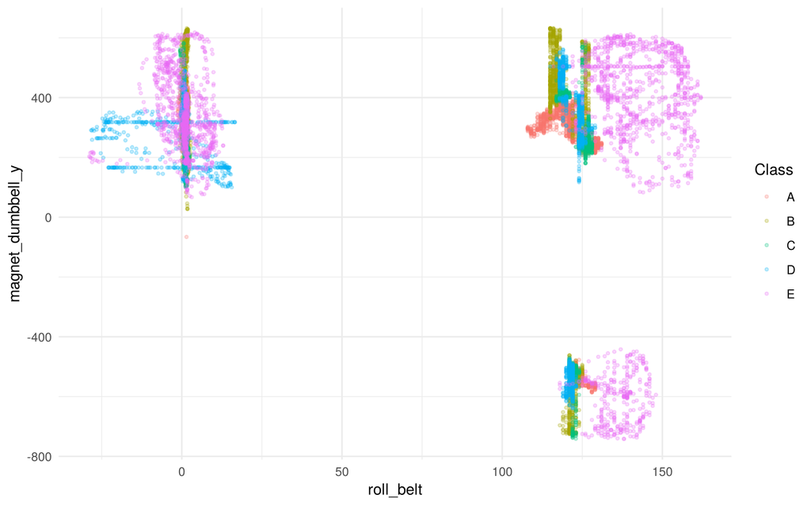

```r
ggplot(train_set, aes(roll_belt, magnet_dumbbell_y, colour = classe)) +
  geom_point(alpha = 0.25, size = 0.8) +
  labs(x = "roll_belt", y = "magnet_dumbbell_y", colour = "Class") +
  theme_minimal()
```

## 6. Model building

### 6.1 Model 1 — Decision tree (baseline)

A single classification tree is easy to interpret and quick to fit, so it makes a useful baseline.

```r
set.seed(12345)
mod_tree  <- train(classe ~ ., data = train_set, method = "rpart",
                   trControl = cv_control, tuneLength = 10)
pred_tree <- predict(mod_tree, valid_set)
cm_tree   <- confusionMatrix(pred_tree, valid_set$classe)
cm_tree$overall[c("Accuracy", "Kappa")]
```

```
##  Accuracy     Kappa
## 0.6807137 0.5966067
```

### 6.2 Model 2 — Random forest

A random forest averages hundreds of trees, each grown on a bootstrap sample with a random subset of predictors at every split. It handles nonlinear boundaries and interactions between sensors, needs no scaling, and is robust to correlated predictors — a good fit for this data. I use 200 trees to keep run time reasonable; accuracy levels off well before that.

```r
set.seed(12345)
mod_rf  <- train(classe ~ ., data = train_set, method = "rf",
                 trControl = cv_control, ntree = 200, importance = TRUE)
mod_rf
```

```
## Random Forest
##
## 13737 samples
##    52 predictor
##     5 classes: 'A', 'B', 'C', 'D', 'E'
##
## No pre-processing
## Resampling: Cross-Validated (5 fold)
## Summary of sample sizes: 10990, 10990, 10989, 10991, 10988
## Resampling results across tuning parameters:
##
##   mtry  Accuracy   Kappa
##    2    0.9915557  0.9893172
##   27    0.9907545  0.9883041
##   52    0.9834749  0.9790956
##
## Accuracy was used to select the optimal model using the largest value.
## The final value used for the model was mtry = 2.
```

```r
pred_rf <- predict(mod_rf, valid_set)
cm_rf   <- confusionMatrix(pred_rf, valid_set$classe)
cm_rf
```

```
## Confusion Matrix and Statistics
##
##           Reference
## Prediction    A    B    C    D    E
##          A 1673    7    0    0    0
##          B    1 1132    6    0    0
##          C    0    0 1020   24    0
##          D    0    0    0  938    0
##          E    0    0    0    2 1082
##
## Overall Statistics
##
##                Accuracy : 0.9932
##                  95% CI : (0.9908, 0.9951)
##     No Information Rate : 0.2845
##     P-Value [Acc > NIR] : < 2.2e-16
##
##                   Kappa : 0.9914
##
##  Mcnemar's Test P-Value : NA
##
## Statistics by Class:
##
##                      Class: A Class: B Class: C Class: D Class: E
## Sensitivity            0.9994   0.9939   0.9942   0.9730   1.0000
## Specificity            0.9983   0.9985   0.9951   1.0000   0.9996
## Pos Pred Value         0.9958   0.9939   0.9770   1.0000   0.9982
## Neg Pred Value         0.9998   0.9985   0.9988   0.9947   1.0000
## Prevalence             0.2845   0.1935   0.1743   0.1638   0.1839
## Detection Rate         0.2843   0.1924   0.1733   0.1594   0.1839
## Detection Prevalence   0.2855   0.1935   0.1774   0.1594   0.1842
## Balanced Accuracy      0.9989   0.9962   0.9946   0.9865   0.9998
```

### 6.3 Comparison

```r
results <- data.frame(
  Model = c("Decision tree (rpart)", "Random forest"),
  CV_accuracy = c(max(mod_tree$results$Accuracy), max(mod_rf$results$Accuracy)),
  Validation_accuracy = c(cm_tree$overall["Accuracy"], cm_rf$overall["Accuracy"])
)
results$Out_of_sample_error <- 1 - results$Validation_accuracy
knitr::kable(results, digits = 4,
             col.names = c("Model", "5-fold CV accuracy", "Validation accuracy",
                           "Estimated out-of-sample error"))
```

| Model | 5-fold CV accuracy | Validation accuracy | Estimated out-of-sample error |
| --- | --- | --- | --- |
| Decision tree (rpart) | 0.6912 | 0.6807 | 0.3193 |
| Random forest | 0.9916 | 0.9932 | 0.0068 |

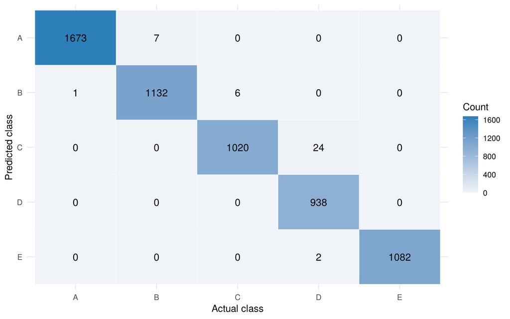

Figure 2. Random-forest confusion matrix on the 30 % validation set (counts). Almost all predictions fall on the diagonal.

```r
cm_df <- as.data.frame(cm_rf$table)
ggplot(cm_df, aes(Reference, Prediction, fill = Freq)) +
  geom_tile(colour = "white") +
  geom_text(aes(label = Freq), size = 4) +
  scale_fill_gradient(low = "#f0f4f8", high = "#2c7fb8") +
  scale_y_discrete(limits = rev(levels(cm_df$Prediction))) +
  labs(x = "Actual class", y = "Predicted class", fill = "Count") +
  theme_minimal()
```

The decision tree reaches only about 68.1% accuracy, while the random forest reaches **99.32%** on data it has never seen.

### 6.4 Which sensors matter most

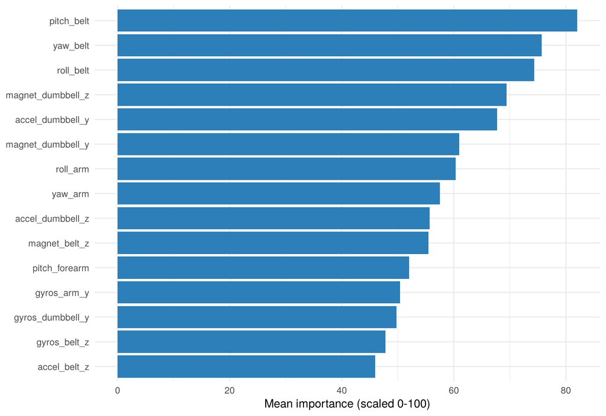

Figure 3. Top 15 predictors by random-forest importance.

```r
imp <- varImp(mod_rf)$importance
imp$Overall <- rowMeans(imp)
imp$feature <- rownames(imp)
top <- head(imp[order(-imp$Overall), ], 15)
ggplot(top, aes(reorder(feature, Overall), Overall)) +
  geom_col(fill = "#2c7fb8") + coord_flip() +
  labs(x = NULL, y = "Mean importance (scaled 0-100)") +
  theme_minimal()
```

Belt orientation (`roll_belt`, `yaw_belt`, `pitch_belt`) and the dumbbell’s magnetometer and acceleration readings are the most informative — sensible, since hip-throwing (E) and partial lifts (C, D) change belt and dumbbell motion the most.

## 7. Expected out-of-sample error

The out-of-sample error is the error rate on new data the model was not trained on. My best estimate comes from the 30 % validation set, which played no part in fitting or tuning:

- **Validation accuracy:** 99.32% (95 % CI 99.08% – 99.51%)
- **Expected out-of-sample error:** about **0.68%**

One caveat: the 20 test cases come from the same six people, so this error estimate applies to those participants. For a brand-new person, accuracy would likely be lower, because each person moves a little differently.

## 8. Predicting the 20 test cases

```r
final_pred <- predict(mod_rf, testing)
answers <- data.frame(problem_id = testing_raw$problem_id, classe = final_pred)
knitr::kable(t(answers), col.names = NULL)
```

| problem_id | 1 | 2 | 3 | 4 | 5 | 6 | 7 | 8 | 9 | 10 | 11 | 12 | 13 | 14 | 15 | 16 | 17 | 18 | 19 | 20 |
| --- | --- | --- | --- | --- | --- | --- | --- | --- | --- | --- | --- | --- | --- | --- | --- | --- | --- | --- | --- | --- |
| classe | B | A | B | A | A | E | D | B | A | A | B | C | B | A | E | E | A | B | B | B |

```r
write.csv(answers, "test_predictions.csv", row.names = FALSE)
```

## 9. Why these choices

- **Dropping mostly-empty and ID columns** keeps only information that exists for every test case and describes the movement itself.
- **Random forest over a single tree**, because the classes overlap in complex ways (Figure 1) and the forest’s averaging gives much higher accuracy with little risk of overfitting.
- **5-fold cross-validation plus a separate hold-out set**, so tuning and error estimation never use the same data.
- **No extra preprocessing** (centring, scaling, PCA), because tree-based models do not need it and the random forest already performs near ceiling.

## 10. Reference

Velloso, E.; Bulling, A.; Gellersen, H.; Ugulino, W.; Fuks, H. *Qualitative Activity Recognition of Weight Lifting Exercises.* Proceedings of the 4th International Conference in Cooperation with SIGCHI (Augmented Human ’13). Stuttgart, Germany: ACM SIGCHI, 2013.

```
## Report built with R version 4.3.3 (2024-02-29)
```